# Interactive map tutorial

Jahred Liddie

2023-11-27

# Task 1a: simple static maps using `ggplot`

First, check out what the `sf` dataframes look like compared to typical dataframes. Then, we’ll review how to make a basic, static map in R using `ggplot`.

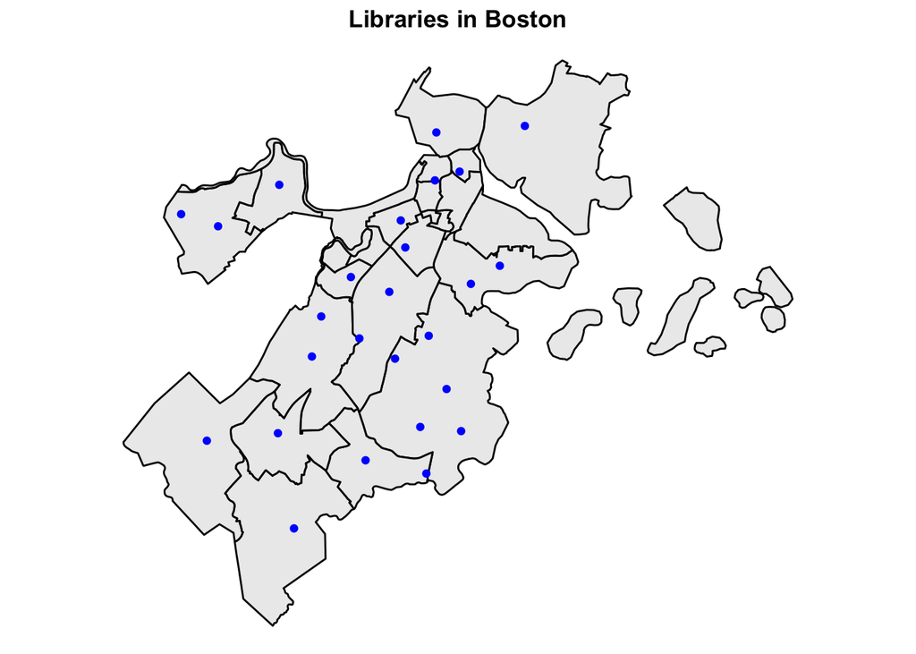

```r
# basic map
ggplot(nhoods) +
  geom_sf(alpha = 0.75, linewidth = 0.5, color = "black") +
  geom_sf(data = libraries, color = "blue") +
  labs(title = "Libraries in Boston") +
  theme_void() +
  theme(plot.title = element_text(hjust = 0.5, face = "bold"))
```

You can also quickly add a basemap using `ggmap`.

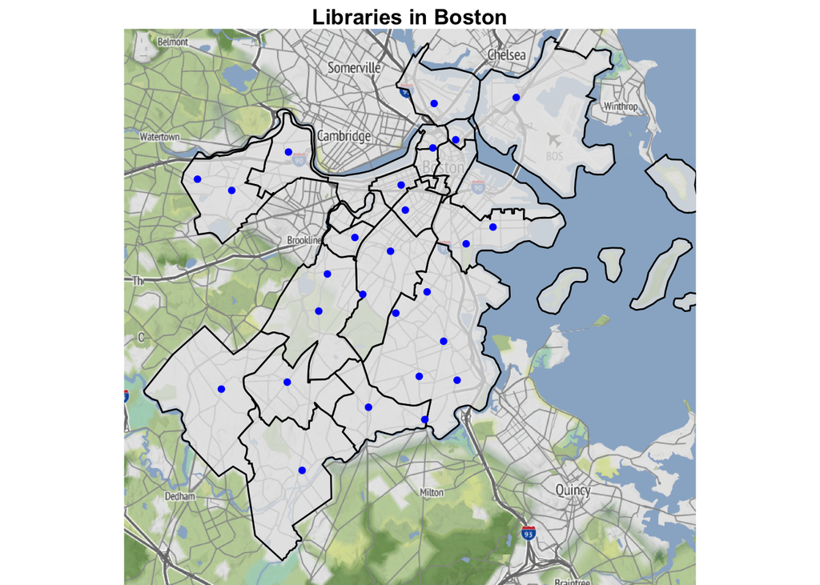

```r
# it's also possible to search the API for Boston's coordinates,
  # but here they are (using StadiaMap, which also requires a key)
boston_basemap <- get_stadiamap(c(left = -71.2, bottom = 42.22,
                                  right = -70.95, top = 42.4), zoom = 12)

# Note: Stadia has mapping tools (incl. basemaps) and it now hosts Stamen maps,
  # which formerly had a lot of free basemaps of the globe. The actual data
  # come from OpenStreetMap, which is a free, open-source geodatabase.
# Carto/CartoDB is another similar application.

# basic map
ggmap(boston_basemap) +
  geom_sf(data = nhoods, alpha = 0.75,
          linewidth = 0.5, color = "black", inherit.aes = FALSE) +
  geom_sf(data = libraries, color = "blue", inherit.aes = FALSE) +
  labs(title = "Libraries in Boston") +
  theme_void() +
  theme(plot.title = element_text(hjust = 0.5, face = "bold"))
```

# Task 1b: A simple static map using `tmap`

I’m generally less familiar with `tmap` but it can be used to quickly make maps (including interactive maps). I sometimes use `tmap` to make sure that a spatial operation or function worked as I intended. Note that maps can also be made in base R (using `plot`).

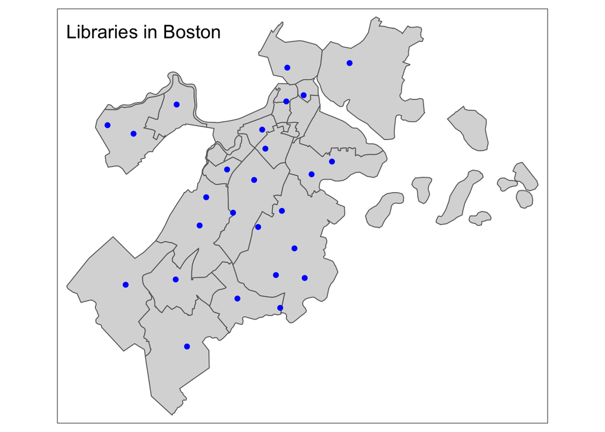

```r
tmap_mode(mode = "plot") # this is actually the default

# this is generally similar to ggplot syntax, but need to specify
 # tm_shape for each new layer
 # I think basemaps can also be added directly using tmap

tm_shape(nhoods) +
  tm_polygons() +
  tm_shape(libraries) +
  tm_dots(size = 0.15, col = "blue") +
  tm_layout(title = "Libraries in Boston")
```

# Task 2: A simple interactive map using `leaflet`

There are other methods to create interactive maps in R, but we’ll start with a simple approach using the `leaflet` package.

In the plot below, we plot the Boston neighborhood dataset again with locations of the libraries on top of it. We give the Boston neighborhoods a “highlight” color when our cursor hovers over them. We also put a basemap behind our plotted data.

```r
# in R, leaflet generally has ggplot's syntax / structure,
  # but it uses pipes (%>%)
leaflet(nhoods) %>% # this is similar to 'ggplot'

  # this is similar to 'geom_sf'; weight controls line thickness
  # you can also remove borders
  addPolygons(group = "Boston neighborhoods", weight = 2, color = "black",
              fillColor = "blue", fillOpacity = 0.1,
              highlightOptions = highlightOptions(fillColor = "darkblue",
                                                  fillOpacity = 1)) %>%

  # this is more specific to points - note the different arguments
  addCircles(data = libraries, group = "Libraries",
             color = "red", opacity = 1, radius = 0.5) %>%

  # this is similar to ggmap; see `providers' for a list of options
  addProviderTiles(providers$CartoDB.Positron)
```

[interactive chart not shown]

# Task 3: A more complicated interactive map using `leaflet`

In the plot below, we extend our previous plot by adding labels for polygons and text popups for points. We limit the plot view for our audience. We also include control options, such that certain layers (which we specify) can be added or removed from the map.

```r
# easy way to retrieve bounds of an 'sf' object
limits <- st_bbox(nhoods)

leaflet(nhoods) %>%

  addPolygons(group = "Boston neighborhoods", weight = 2, color = "black",
              fillColor = "blue", fillOpacity = 0.1,
              label = nhoods$blockgr2020_ctr_neighb_name,
              highlightOptions = highlightOptions(fillColor = "darkblue",
                                                  fillOpacity = 1)) %>%

  # now we also add very simple popups
  addCircles(data = libraries, group = "Libraries",
             popup = libraries$BRANCH,
             color = "red", opacity = 1, weight = 5) %>%

  addCircles(data = foodtrucks, group = "Food trucks",
             popup = foodtrucks$Truck,
             color = "green", opacity = 1, weight = 4) %>%

  addProviderTiles(providers$CartoDB.Positron) %>%

  # these are the control options for the map
    # note that tiles can also be controlled
  addLayersControl(
    position = "bottomright",
    baseGroups = "Boston neighborhoods", # needs to match `group` name above
    overlayGroups = c("Libraries", "Food trucks")) %>%

  # now add bounds to map to limit scrolling
  setMaxBounds(lng1 = as.numeric(limits[1]) - 0.1,
               lat1 = as.numeric(limits[2]) - 0.1,
               lng2 = as.numeric(limits[3]) + 0.1,
               lat2 = as.numeric(limits[4]) + 0.1
              )
```

[interactive chart not shown]

# Task 4: A simple interactive map using `tmap`

Now let’s do something similar with `tmap`. In general, `leaflet` seems more customizable. By default, it `tmap` shows a lot more information.

```r
tmap_mode(mode = "view") # this is how to specify interactive mapping

tm_shape(nhoods) +
  tm_polygons() +
  tm_shape(libraries) +
  tm_dots(size = 0.05, col = "blue") +
  tm_layout(title = "Libraries in Boston")
```

[interactive chart not shown]

# More resources

See [here](https://rstudio.github.io/leaflet/) for a more in-depth tutorial of `leaflet`, including how to integrate them with `RShiny`.

See [here](https://cran.r-project.org/web/packages/tmap/vignettes/tmap-getstarted.html) for more info on `tmap`.

There are more options out there to make interactive maps, either using R, other programming languages, or software tools (e.g., ArcGIS storymaps). [Here](https://bookdown.org/nicohahn/making_maps_with_r5/docs/introduction.html) are some more examples with R.